# Waymo Project

2026-03-03

# Introduction

Autonomous vehicles (AVs) must safely navigate dynamic urban environments involving vehicles, cyclists, and pedestrians. Two major challenges in this setting are detecting anomalous driving behavior and predicting short-term future motion of surrounding agents.

This project addresses both challenges using trajectory data derived from the Waymo Open Dataset. Specifically, we aim to:

- Detect anomalous motion patterns using unsupervised learning.
- Predict 5-second future displacement using supervised regression.
- Compare results when stationary agents are included versus removed.

# State-of-the-Art

Modern autonomous driving systems rely heavily on:

- Trajectory forecasting models (Kalman Filters, LSTMs, Transformers)
- Unsupervised anomaly detection (Isolation Forest, One-Class SVM)
- Multi-agent interaction models

Short-horizon forecasting (3–5 seconds) is often modeled using kinematic state variables. Isolation Forest remains widely used due to its scalability and minimal distributional assumptions.

# Materials and Methods

## Dataset

For each agent, kinematic features are extracted at the prediction horizon (t = 0). The feature set includes:

- **Speed (v)**: Magnitude of the velocity vector (m/s).
- **Acceleration (a)**: Rate of change of speed (m/s²).
- **Yaw Rate (ψ̇)**: Angular velocity representing the rate of change of heading (rad/s).

## Pipeline

1. Raw Waymo Motion Dataset extracted using Python (see `src/python/waymo.ipynb`).
2. Dataset exported as CSV.
3. Correlation EDA → Isolation Forest anomaly detection → Linear regression for motion prediction.

## Pre-processing

- Removed invalid frames (`Valid_Current != True`)
- Removed stationary agents (`Speed > 0`)
- Removed missing values in predictors

# Code Implementation

```r
library(tidyverse)
library(caret)
library(isotree)
library(e1071)
library(gridExtra)
library(car)
library(showtext)
set.seed(42)

# --- Waymo Font (Latin Modern Roman — the actual LaTeX font) ---
font_add("LM Roman",
         regular  = "~/Library/Fonts/lmroman10-regular.otf",
         bold     = "~/Library/Fonts/lmroman10-bold.otf",
         italic   = "~/Library/Fonts/lmroman10-italic.otf")
showtext_auto()
showtext_opts(dpi = 300)

# --- Waymo Color Palette ---
waymo_green <- "#00C389"
waymo_blue  <- "#1A73E8"
waymo_grey  <- "#8A8F94"
waymo_navy  <- "#1F233F"
waymo_white <- "#FFFFFF"

waymo_2col    <- c("With Stationary"    = waymo_blue,  "Without Stationary" = waymo_green)
waymo_3col    <- c("Cyclist"            = waymo_grey,  "Pedestrian"         = waymo_green,
                   "Vehicle"            = waymo_blue)
waymo_anomaly <- c("No"                 = waymo_green, "Yes"                = waymo_navy)
waymo_feat    <- c("Speed"              = waymo_blue,  "Acceleration"       = waymo_green,
                   "YawRate"            = waymo_grey)

# --- Waymo ggplot Theme ---
waymo_theme <- function(base_size = 12) {
  theme_minimal(base_size = base_size) +
  theme(
    text             = element_text(family = "LM Roman", color = waymo_navy),
    plot.title       = element_text(face = "bold", size = base_size + 2, color = waymo_navy),
    plot.subtitle    = element_text(size = base_size - 1, color = waymo_grey),
    axis.text        = element_text(color = waymo_navy),
    axis.title       = element_text(color = waymo_navy),
    panel.grid.major = element_line(color = "#E8EAED"),
    panel.grid.minor = element_blank(),
    legend.text      = element_text(color = waymo_navy),
    legend.title     = element_text(color = waymo_navy, face = "bold"),
    plot.background  = element_rect(fill = waymo_white, color = NA),
    panel.background = element_rect(fill = waymo_white, color = NA),
    strip.text       = element_text(color = waymo_navy, face = "bold")
  )
}
```

```r
data <- read.csv("/Users/justincabrera/Documents/Statistical Learning/Datasets/waymo_final_dataset.csv")
cat("Total rows in raw dataset:", nrow(data), "\n")
```

```
## Total rows in raw dataset: 18311
```

```r
# Pre-processing
data_clean <- data %>%
  filter(Speed != 0) %>%
  filter(Valid_Current == "True") %>%
  drop_na(Speed, Acceleration, YawRate, Length, Width)

data_clean$AgentType <- as.factor(data_clean$AgentType)
cat("Final cleaned dataset size:", nrow(data_clean), "\n")
```

```
## Final cleaned dataset size: 4538
```

# 1. Correlation EDA

*Starting with EDA to understand feature relationships before modeling.*

```r
kinematic_vars <- c("Speed", "Acceleration", "YawRate", "Length", "Width")
cor_matrix <- cor(data_clean[, kinematic_vars], use = "complete.obs")
cat("=== Pearson Correlation Matrix ===\n")
```

```
## === Pearson Correlation Matrix ===
```

```r
print(round(cor_matrix, 3))
```

```
##              Speed Acceleration YawRate Length  Width
## Speed        1.000        0.173   0.022  0.282  0.276
## Acceleration 0.173        1.000   0.093  0.063  0.041
## YawRate      0.022        0.093   1.000 -0.008 -0.005
## Length       0.282        0.063  -0.008  1.000  0.969
## Width        0.276        0.041  -0.005  0.969  1.000
```

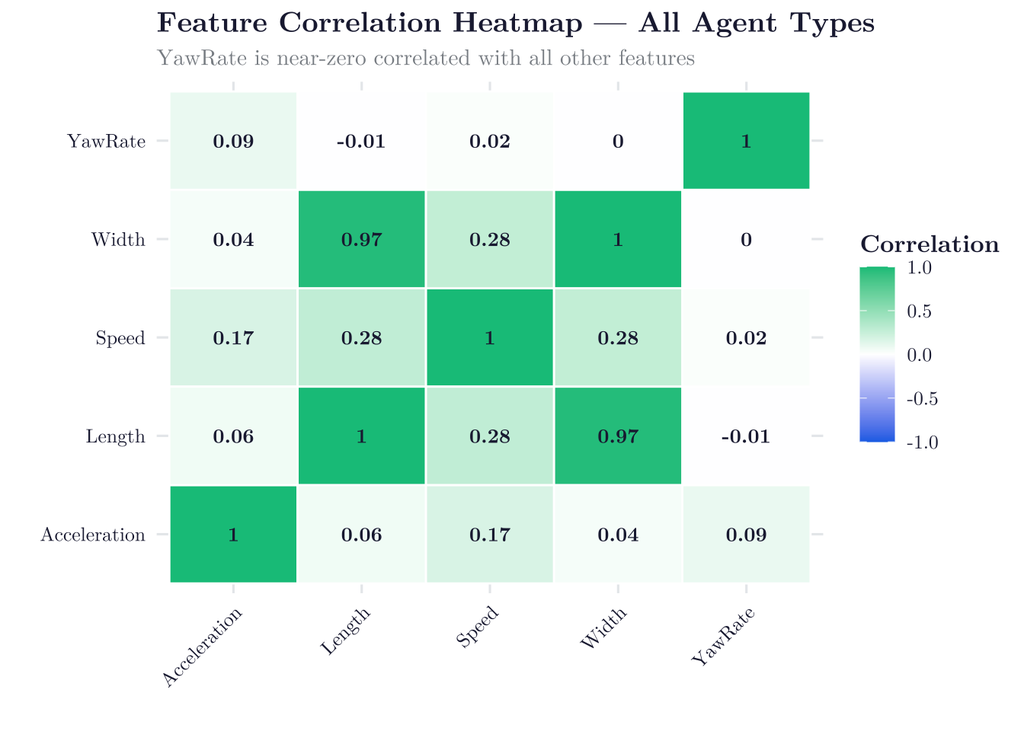

```r
# Correlation heatmap
cor_df <- as.data.frame(cor_matrix) %>%
  rownames_to_column("Var1") %>%
  pivot_longer(-Var1, names_to = "Var2", values_to = "Correlation")

dir.create("../../docs/images", recursive = TRUE, showWarnings = FALSE)

p_heatmap <- ggplot(cor_df, aes(x = Var1, y = Var2, fill = Correlation)) +
  geom_tile(color = waymo_white, linewidth = 0.5) +
  geom_text(aes(label = round(Correlation, 2)), size = 3.5, fontface = "bold",
            color = waymo_navy, family = "LM Roman") +
  scale_fill_gradient2(low = waymo_blue, mid = waymo_white, high = waymo_green,
                       midpoint = 0, limits = c(-1, 1)) +
  labs(title = "Feature Correlation Heatmap — All Agent Types",
       subtitle = "YawRate is near-zero correlated with all other features",
       x = "", y = "") +
  waymo_theme() +
  theme(axis.text.x = element_text(angle = 45, hjust = 1))

ggsave("../../docs/images/correlation_heatmap.png", plot = p_heatmap,
       width = 7, height = 6, dpi = 300, type = "cairo")
p_heatmap
```

```r
# Descriptive summary
summary(data_clean[, c("Speed", "Acceleration", "YawRate")])
```

```
##      Speed            Acceleration           YawRate
##  Min.   : 0.000108   Min.   :-106.54081   Min.   :-3.139e+01
##  1st Qu.: 0.637165   1st Qu.:  -1.18297   1st Qu.:-2.315e-02
##  Median : 3.684197   Median :   0.03722   Median : 2.920e-05
##  Mean   : 5.898626   Mean   :   0.52535   Mean   :-1.273e-02
##  3rd Qu.: 9.980105   3rd Qu.:   1.70492   3rd Qu.: 2.642e-02
##  Max.   :49.752234   Max.   : 355.77651   Max.   : 3.134e+01
```

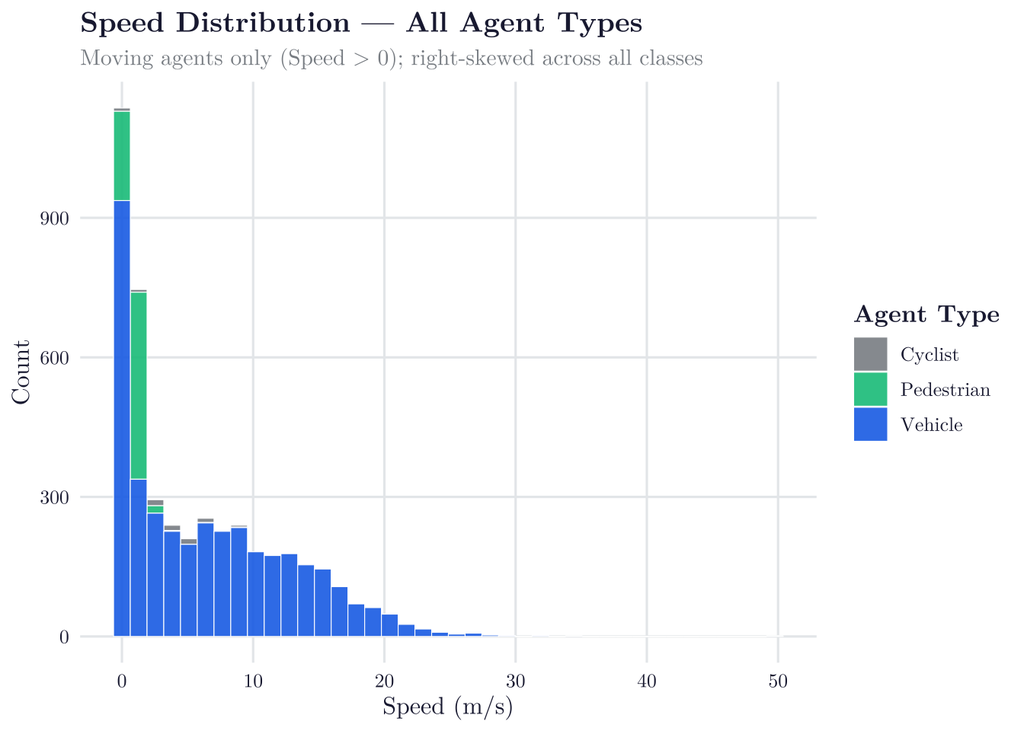

```r
p_speed <- ggplot(data_clean, aes(x = Speed, fill = AgentType)) +
  geom_histogram(bins = 40, color = waymo_white, linewidth = 0.2, alpha = 0.9) +
  scale_fill_manual(values = waymo_3col) +
  labs(title    = "Speed Distribution — All Agent Types",
       subtitle = "Moving agents only (Speed > 0); right-skewed across all classes",
       x        = "Speed (m/s)",
       y        = "Count",
       fill     = "Agent Type") +
  waymo_theme()

ggsave("../../docs/images/speed_distribution.png", plot = p_speed,
       width = 8, height = 5, dpi = 300, type = "cairo")
p_speed
```

```r
cat("Speed skewness:", e1071::skewness(data_clean$Speed), "\n")
```

```
## Speed skewness: 1.040441
```

```r
cat("99th percentile acceleration:", quantile(data_clean$Acceleration, 0.99), "\n")
```

```
## 99th percentile acceleration: 18.98356
```

# 2. Isolation Forest — Anomaly Detection

*YawRate’s independence from other features makes it a strong candidate for anomaly isolation.*

```r
iso_model <- isolation.forest(
  data_clean[, c("Speed", "Acceleration", "YawRate")],
  ntrees   = 100,
  nthreads = 1
)

data_clean$AnomalyScore <- predict(
  iso_model,
  data_clean[, c("Speed", "Acceleration", "YawRate")]
)

score_threshold <- quantile(data_clean$AnomalyScore, 0.99)

data_clean$Is_Anomaly <- as.factor(
  ifelse(data_clean$AnomalyScore > score_threshold, "Yes", "No")
)

cat("Anomaly threshold (99th percentile):", score_threshold, "\n")
```

```
## Anomaly threshold (99th percentile): 0.5566879
```

```r
table(data_clean$Is_Anomaly)
```

```
##
##   No  Yes
## 4492   46
```

```r
# Who are the anomalous agents?
anomalous_agents <- data_clean %>%
  filter(Is_Anomaly == "Yes") %>%
  select(ScenarioID, AgentID, AgentType, Speed, Acceleration,
         YawRate, Length, Width, AnomalyScore, IsInteractive) %>%
  arrange(desc(AnomalyScore))

cat("Total flagged:", nrow(anomalous_agents), "\n\n")
```

```
## Total flagged: 46
```

```r
cat("=== Breakdown by Agent Type ===\n")
```

```
## === Breakdown by Agent Type ===
```

```r
print(table(anomalous_agents$AgentType))
```

```
##
##    Cyclist Pedestrian    Vehicle
##          1         16         29
```

```r
cat("\n=== Top 20 Most Anomalous Agents ===\n")
```

```
##
## === Top 20 Most Anomalous Agents ===
```

```r
print(head(anomalous_agents, 20))
```

```
##          ScenarioID AgentID  AgentType      Speed Acceleration     YawRate
## 1  909244b878c6c203    1409    Vehicle 49.7522337  355.7765102   0.0486517
## 2   5baef16beff3351    1554    Vehicle 24.9215469  230.9987003  30.6366062
## 3  c014d3c05600714f     560    Vehicle 32.4343447  239.8659613  -0.3366148
## 4  3eea09dc81191856     998    Vehicle  3.4746838   19.7094995  31.3370997
## 5  bd094f42eeab6700     510 Pedestrian  9.5352089   88.6511891  -3.9872074
## 6  cffef7d3778fc611    1265    Vehicle 17.0366753    0.0000000 -16.9537614
## 7  2c4cec5c3ea292e2    2861    Vehicle  2.4566565   -4.5194379 -31.2079055
## 8  27597bc952d2c9c7     891    Vehicle 14.4440623    0.0000000  15.6420417
## 9  2f8f82f1072ad710      55    Vehicle  0.2344259   -8.3543391 -30.9017069
## 10 262112a66742fe8d    1478    Vehicle  5.1041841  -31.3226886  14.8376394
## 11 d3fd8cb194ea76f6    1093    Vehicle  2.3305509    0.0000000 -30.9164745
## 12 262112a66742fe8d    3661 Pedestrian  0.9353263    0.0000000  31.2191040
## 13 e62ae31ead55e09c    1150 Pedestrian  0.8380400 -106.5408093   0.0500226
## 14 308716b64a079919    1571    Vehicle  0.7276466    3.8814288 -31.3147648
```

[output cut: 27 more lines]

```r
cat("\n=== Summary Statistics ===\n")
```

```
##
## === Summary Statistics ===
```

```r
print(summary(anomalous_agents[, c("Speed", "Acceleration", "YawRate", "AnomalyScore")]))
```

```
##      Speed          Acceleration         YawRate           AnomalyScore
##  Min.   : 0.0594   Min.   :-106.541   Min.   :-31.39499   Min.   :0.5570
##  1st Qu.: 0.4509   1st Qu.:  -3.506   1st Qu.:-12.70125   1st Qu.:0.5924
##  Median : 3.1044   Median :   0.000   Median : -0.04822   Median :0.6486
##  Mean   :10.6504   Mean   :  21.131   Mean   : -2.09286   Mean   :0.6583
##  3rd Qu.:20.4573   3rd Qu.:  30.414   3rd Qu.:  0.28159   3rd Qu.:0.7042
##  Max.   :49.7522   Max.   : 355.777   Max.   : 31.33710   Max.   :0.8698
```

```r
cat("\n=== % flagged as Interactive by Waymo ===\n")
```

```
##
## === % flagged as Interactive by Waymo ===
```

```r
print(prop.table(table(anomalous_agents$IsInteractive)))
```

```
##
## False
##     1
```

```r
# Fisher's Exact Test: is anomaly rate associated with AgentType?
contingency_table <- table(data_clean$AgentType, data_clean$Is_Anomaly)
fisher.test(contingency_table, simulate.p.value = TRUE)
```

```
##
##  Fisher's Exact Test for Count Data with simulated p-value (based on
##  2000 replicates)
##
## data:  contingency_table
## p-value = 0.0004998
## alternative hypothesis: two.sided
```

## Isolation Forest Explainability

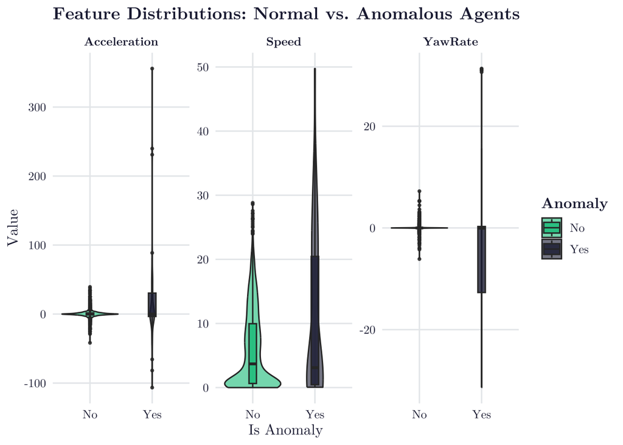

```r
# Feature distributions: normal vs anomalous
data_clean %>%
  select(Speed, Acceleration, YawRate, Is_Anomaly) %>%
  pivot_longer(-Is_Anomaly, names_to = "Feature", values_to = "Value") %>%
  ggplot(aes(x = Is_Anomaly, y = Value, fill = Is_Anomaly)) +
  geom_violin(alpha = 0.6, trim = TRUE) +
  geom_boxplot(width = 0.12, outlier.size = 0.8, alpha = 0.8) +
  facet_wrap(~Feature, scales = "free_y") +
  scale_fill_manual(values = waymo_anomaly) +
  labs(title = "Feature Distributions: Normal vs. Anomalous Agents",
       x = "Is Anomaly", y = "Value", fill = "Anomaly") +
  waymo_theme()
```

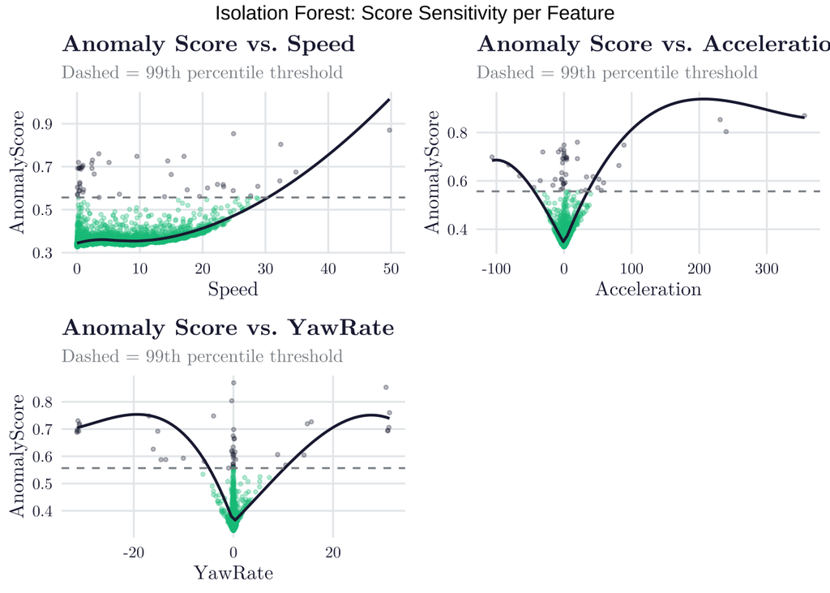

```r
# Anomaly score vs each feature with LOESS
features_to_plot <- c("Speed", "Acceleration", "YawRate")

plots <- lapply(features_to_plot, function(feat) {
  ggplot(data_clean, aes_string(x = feat, y = "AnomalyScore", color = "Is_Anomaly")) +
    geom_point(alpha = 0.3, size = 0.8) +
    geom_smooth(aes(group = 1), method = "loess", se = FALSE,
                color = waymo_navy, linewidth = 0.8) +
    geom_hline(yintercept = score_threshold, linetype = "dashed", color = waymo_grey) +
    scale_color_manual(values = waymo_anomaly) +
    labs(title = paste("Anomaly Score vs.", feat),
         subtitle = "Dashed = 99th percentile threshold") +
    waymo_theme() +
    theme(legend.position = "none")
})

grid.arrange(grobs = plots, ncol = 2,
             top = "Isolation Forest: Score Sensitivity per Feature")
```

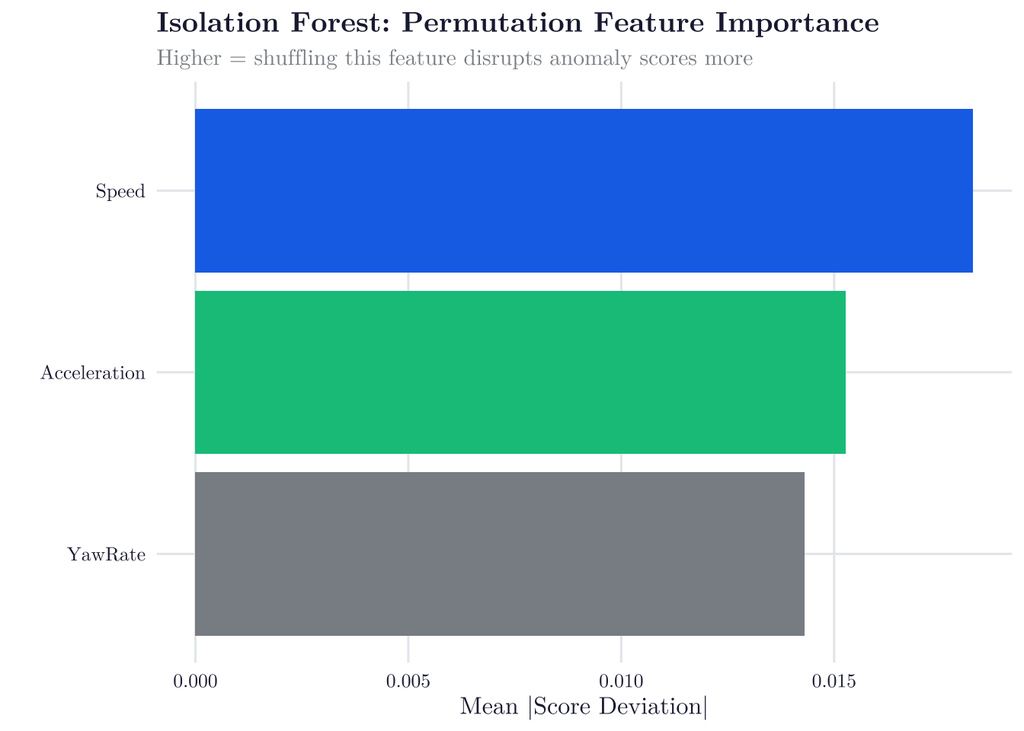

```r
# Permutation feature importance
set.seed(42)
baseline_scores <- data_clean$AnomalyScore

perm_importance <- sapply(features_to_plot, function(feat) {
  shuffled <- data_clean[, features_to_plot]
  shuffled[[feat]] <- sample(shuffled[[feat]])
  perm_scores <- predict(iso_model, shuffled)
  mean(abs(perm_scores - baseline_scores))
})

perm_df <- data.frame(
  Feature    = names(perm_importance),
  Importance = perm_importance
) %>% arrange(desc(Importance))

p_iso_importance <- ggplot(perm_df, aes(x = reorder(Feature, Importance),
                                        y = Importance, fill = Feature)) +
  geom_col(show.legend = FALSE) +
  coord_flip() +
  scale_fill_manual(values = waymo_feat) +
  labs(title    = "Isolation Forest: Permutation Feature Importance",
       subtitle = "Higher = shuffling this feature disrupts anomaly scores more",
       x = "", y = "Mean |Score Deviation|") +
  waymo_theme()

ggsave("../../docs/images/iso_forest_feature_importance.png", plot = p_iso_importance,
       width = 7, height = 5, dpi = 300, type = "cairo")
p_iso_importance
```

```r
print(perm_df)
```

```
##                   Feature Importance
## Speed               Speed 0.01826013
## Acceleration Acceleration 0.01527570
## YawRate           YawRate 0.01430658
```

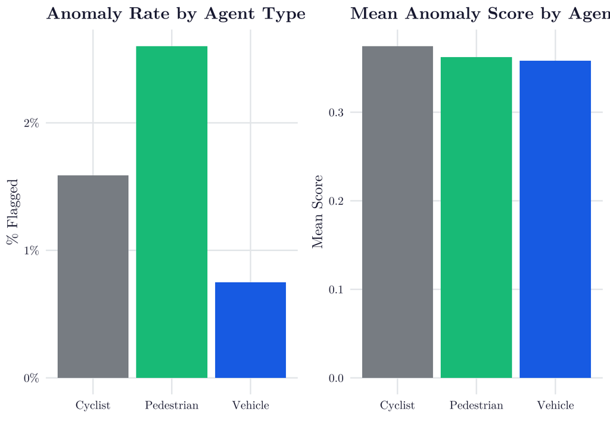

```r
# Anomaly rate and mean score by AgentType
agent_summary <- data_clean %>%
  group_by(AgentType) %>%
  summarise(Count        = n(),
            Anomaly_Rate = mean(Is_Anomaly == "Yes"),
            Mean_Score   = mean(AnomalyScore),
            .groups      = "drop")

p1 <- ggplot(agent_summary, aes(x = AgentType, y = Anomaly_Rate, fill = AgentType)) +
  geom_col(show.legend = FALSE) +
  scale_fill_manual(values = waymo_3col) +
  scale_y_continuous(labels = scales::percent) +
  labs(title = "Anomaly Rate by Agent Type", x = "", y = "% Flagged") +
  waymo_theme()

p2 <- ggplot(agent_summary, aes(x = AgentType, y = Mean_Score, fill = AgentType)) +
  geom_col(show.legend = FALSE) +
  scale_fill_manual(values = waymo_3col) +
  labs(title = "Mean Anomaly Score by Agent Type", x = "", y = "Mean Score") +
  waymo_theme()

g_agent <- arrangeGrob(p1, p2, ncol = 2)
ggsave("../../docs/images/anomaly_rate_by_agent_type.png", plot = g_agent,
       width = 10, height = 5, dpi = 300, type = "cairo")
grid.arrange(p1, p2, ncol = 2)
```

```r
print(agent_summary)
```

```
## # A tibble: 3 × 4
##   AgentType  Count Anomaly_Rate Mean_Score
##   <fct>      <int>        <dbl>      <dbl>
## 1 Cyclist       63      0.0159       0.375
## 2 Pedestrian   615      0.0260       0.363
## 3 Vehicle     3860      0.00751      0.358
```

# 3. Linear Regression — Motion Prediction

```r
# Base cleaned dataset
base_data <- data %>%
  filter(!is.na(Speed), !is.na(Acceleration), !is.na(YawRate),
         !is.na(Vel_X), !is.na(Vel_Y), !is.na(FutureDist_5s))

data_with_stationary <- base_data
data_no_stationary   <- subset(base_data, Speed > 0)

cat("With stationary:", nrow(data_with_stationary), "\n")
```

```
## With stationary: 6614
```

```r
cat("Without stationary:", nrow(data_no_stationary), "\n")
```

```
## Without stationary: 3196
```

```r
# Speed by AgentType (moving only)
cat("\nMean speed by agent type (moving agents):\n")
```

```
##
## Mean speed by agent type (moving agents):
```

```r
aggregate(Speed ~ AgentType, data = data_no_stationary, mean)
```

```
##    AgentType     Speed
## 1    Cyclist 4.2356664
## 2 Pedestrian 0.9600583
## 3    Vehicle 5.4443324
```

```r
run_model <- function(dataset) {
  set.seed(123)
  n           <- nrow(dataset)
  train_index <- sample(1:n, size = 0.8 * n)
  train       <- dataset[train_index, ]
  test        <- dataset[-train_index, ]
  control     <- trainControl(method = "cv", number = 5)

  model <- train(
    FutureDist_5s ~ Speed + Acceleration + YawRate + Vel_X + Vel_Y,
    data      = train,
    method    = "lm",
    trControl = control
  )

  pred <- predict(model, newdata = test)
  rmse <- sqrt(mean((pred - test$FutureDist_5s)^2))
  r2   <- 1 - sum((pred - test$FutureDist_5s)^2) /
              sum((test$FutureDist_5s - mean(test$FutureDist_5s))^2)

  list(RMSE = rmse, R2 = r2, CV_Results = model$results)
}

results_with    <- run_model(data_with_stationary)
results_without <- run_model(data_no_stationary)

cat("=== With Stationary ===\n");    print(results_with)
```

```
## === With Stationary ===
```

```
## $RMSE
## [1] 7.436852
##
## $R2
## [1] 0.8801945
##
## $CV_Results
##   intercept     RMSE  Rsquared      MAE    RMSESD RsquaredSD     MAESD
## 1      TRUE 7.654757 0.8855705 4.107812 0.8918586 0.01545091 0.1546924
```

```r
cat("\n=== Without Stationary ===\n"); print(results_without)
```

```
##
## === Without Stationary ===
```

```
## $RMSE
## [1] 13.14561
##
## $R2
## [1] 0.7275478
##
## $CV_Results
##   intercept     RMSE  Rsquared      MAE    RMSESD RsquaredSD     MAESD
## 1      TRUE 10.05064 0.8601953 7.638598 0.3586844 0.01677369 0.2083537
```

## Regression Explainability

```r
lm_with    <- lm(FutureDist_5s ~ Speed + Acceleration + YawRate + Vel_X + Vel_Y,
                 data = data_with_stationary)
lm_without <- lm(FutureDist_5s ~ Speed + Acceleration + YawRate + Vel_X + Vel_Y,
                 data = data_no_stationary)

summary(lm_with)
```

```
##
## Call:
## lm(formula = FutureDist_5s ~ Speed + Acceleration + YawRate +
##     Vel_X + Vel_Y, data = data_with_stationary)
##
## Residuals:
##     Min      1Q  Median      3Q     Max
## -73.689  -0.975  -0.975  -0.865  37.847
##
## Coefficients:
##              Estimate Std. Error t value Pr(>|t|)
## (Intercept)   0.97478    0.10132   9.621   <2e-16 ***
## Speed         4.62912    0.02006 230.775   <2e-16 ***
## Acceleration -0.18110    0.01700 -10.654   <2e-16 ***
## YawRate      -0.21521    0.12046  -1.787    0.074 .
## Vel_X        -0.02604    0.02563  -1.016    0.310
## Vel_Y         0.01553    0.02412   0.644    0.520
## ---
## Signif. codes:  0 '***' 0.001 '**' 0.01 '*' 0.05 '.' 0.1 ' ' 1
##
## Residual standard error: 7.283 on 6608 degrees of freedom
## Multiple R-squared:  0.8933, Adjusted R-squared:  0.8932
## F-statistic: 1.107e+04 on 5 and 6608 DF,  p-value: < 2.2e-16
```

```r
summary(lm_without)
```

```
##
## Call:
## lm(formula = FutureDist_5s ~ Speed + Acceleration + YawRate +
##     Vel_X + Vel_Y, data = data_no_stationary)
##
## Residuals:
##     Min      1Q  Median      3Q     Max
## -72.101  -4.375  -2.192   6.206  36.019
##
## Coefficients:
##               Estimate Std. Error t value Pr(>|t|)
## (Intercept)   2.879775   0.247180  11.651  < 2e-16 ***
## Speed         4.454299   0.033927 131.290  < 2e-16 ***
## Acceleration -0.167262   0.024172  -6.920 5.45e-12 ***
## YawRate      -0.165061   0.171061  -0.965    0.335
## Vel_X        -0.036595   0.036399  -1.005    0.315
## Vel_Y         0.006057   0.034257   0.177    0.860
## ---
## Signif. codes:  0 '***' 0.001 '**' 0.01 '*' 0.05 '.' 0.1 ' ' 1
##
## Residual standard error: 10.34 on 3190 degrees of freedom
## Multiple R-squared:  0.8487, Adjusted R-squared:  0.8485
## F-statistic:  3580 on 5 and 3190 DF,  p-value: < 2.2e-16
```

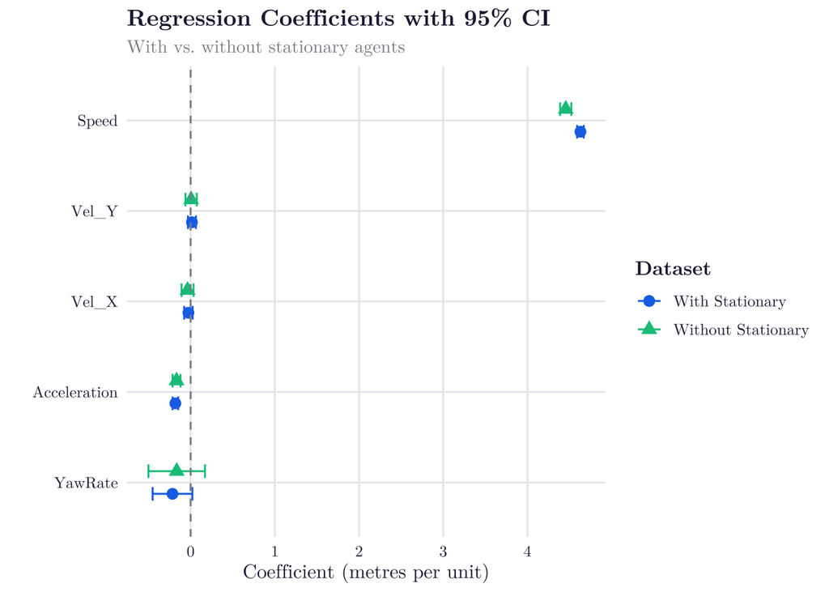

```r
# Coefficient plot with 95% CI — both datasets overlaid
extract_coefs <- function(model, label) {
  ci  <- confint(model)
  est <- coef(model)
  data.frame(Term = rownames(ci), Estimate = est,
             Lower = ci[,1], Upper = ci[,2], Dataset = label,
             stringsAsFactors = FALSE)
}

coef_df <- bind_rows(
  extract_coefs(lm_with,    "With Stationary"),
  extract_coefs(lm_without, "Without Stationary")
) %>% filter(Term != "(Intercept)")

p_coef_ci <- ggplot(coef_df, aes(x = reorder(Term, Estimate), y = Estimate,
                    color = Dataset, shape = Dataset)) +
  geom_point(position = position_dodge(width = 0.5), size = 3) +
  geom_errorbar(aes(ymin = Lower, ymax = Upper),
                position = position_dodge(width = 0.5), width = 0.3) +
  geom_hline(yintercept = 0, linetype = "dashed", color = waymo_grey) +
  coord_flip() +
  scale_color_manual(values = waymo_2col) +
  labs(title    = "Regression Coefficients with 95% CI",
       subtitle = "With vs. without stationary agents",
       x = "", y = "Coefficient (metres per unit)") +
  waymo_theme()

ggsave("../../docs/images/regression_coefficients_ci.png", plot = p_coef_ci,
       width = 8, height = 5, dpi = 300, type = "cairo")
p_coef_ci
```

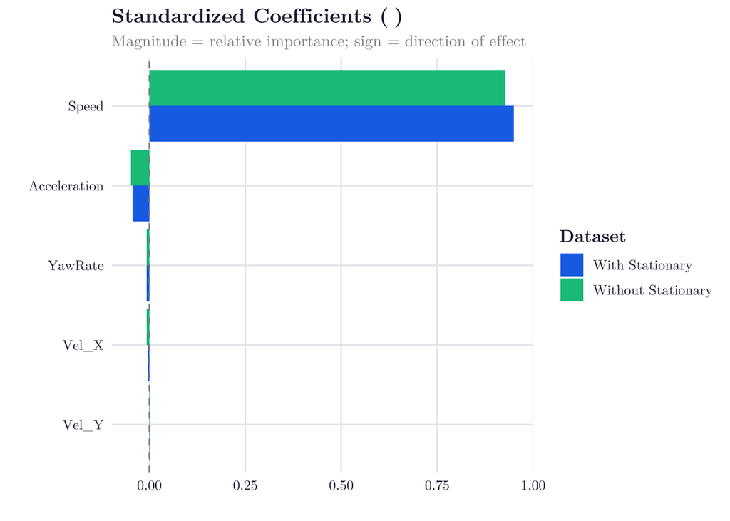

```r
# Standardized beta coefficients
scale_df <- function(df) {
  df %>% mutate(across(c(Speed, Acceleration, YawRate, Vel_X, Vel_Y, FutureDist_5s),
                       ~ as.numeric(scale(.))))
}

lm_with_std    <- lm(FutureDist_5s ~ Speed + Acceleration + YawRate + Vel_X + Vel_Y,
                     data = scale_df(data_with_stationary))
lm_without_std <- lm(FutureDist_5s ~ Speed + Acceleration + YawRate + Vel_X + Vel_Y,
                     data = scale_df(data_no_stationary))

std_coef_df <- bind_rows(
  data.frame(Term = names(coef(lm_with_std)[-1]),
             Beta = coef(lm_with_std)[-1], Dataset = "With Stationary"),
  data.frame(Term = names(coef(lm_without_std)[-1]),
             Beta = coef(lm_without_std)[-1], Dataset = "Without Stationary")
)

p_std_coef <- ggplot(std_coef_df, aes(x = reorder(Term, abs(Beta)), y = Beta, fill = Dataset)) +
  geom_col(position = "dodge") +
  coord_flip() +
  geom_hline(yintercept = 0, linetype = "dashed", color = waymo_grey) +
  scale_fill_manual(values = waymo_2col) +
  labs(title    = "Standardized Coefficients (β)",
       subtitle = "Magnitude = relative importance; sign = direction of effect",
       x = "", y = "β") +
  waymo_theme()

ggsave("../../docs/images/regression_feature_importance.png", plot = p_std_coef,
       width = 7, height = 5, dpi = 300, type = "cairo")
p_std_coef
```

```r
print(std_coef_df)
```

```
##                          Term         Beta            Dataset
## Speed...1               Speed  0.950163626    With Stationary
## Acceleration...2 Acceleration -0.043643234    With Stationary
## YawRate...3           YawRate -0.007180868    With Stationary
## Vel_X...4               Vel_X -0.004174500    With Stationary
## Vel_Y...5               Vel_Y  0.002595326    With Stationary
## Speed...6               Speed  0.926895121 Without Stationary
## Acceleration...7 Acceleration -0.048643744 Without Stationary
## YawRate...8           YawRate -0.006648772 Without Stationary
## Vel_X...9               Vel_X -0.007068292 Without Stationary
## Vel_Y...10              Vel_Y  0.001221787 Without Stationary
```

```r
# VIF — multicollinearity check
cat("=== VIF: With Stationary ===\n");    print(vif(lm_with))
```

```
## === VIF: With Stationary ===
```

```
##        Speed Acceleration      YawRate        Vel_X        Vel_Y
##     1.050009     1.039438     1.000632     1.045965     1.006743
```

```r
cat("\n=== VIF: Without Stationary ===\n"); print(vif(lm_without))
```

```
##
## === VIF: Without Stationary ===
```

```
##        Speed Acceleration      YawRate        Vel_X        Vel_Y
##     1.051213     1.042264     1.001352     1.042484     1.007020
```